# Getting started with R and diet data

Sarah Gaichas

6/16/2021

## R Basics

This document has “code chunks” that should help get started with using R to analyze and visualize the fish diet data that Brian provided.

### Try something simple

R can do basic calculations right from the “Console” when you type them in at the `>` prompt.

Try typing in `2+2` at the `>` prompt and see what happens.

### Reading data into R

The diet dataset is called `allwt2.csv` and I have downloaded it from the google drive and put it in a folder called `data`. It is easy to read data in to R, but the hard part is usually having R know where to look for the data. I can tell R where to look for it on my computer in order to read it in, or I can read it directly from the google drive.

In the first line below, I tell R to use the package called `here` which establishes the place on my computer where I am running my session as the place to look. The second line below reads the file using the R command `read.csv` on the file `allwt2.csv` that is located in the `data` folder.

```r
library(here)
dietdat1 <- read.csv(here("data/allwt2.csv"))
```

If we type `dietdat1` at the prompt, we see the some or all of the datafile, depending on how long it is.

```r
dietdat1
```

```
##         X svspp epu season year nstom   meanlen      varlen numlen minlen
## 1       1    13  GB   FALL 1973    NA        NA          NA     NA     NA
## 2       2    13  GB   FALL 1974    NA        NA          NA     NA     NA
## 3       3    13  GB   FALL 1975    NA        NA          NA     NA     NA
## 4       4    13  GB   FALL 1976    NA        NA          NA     NA     NA
## 5       5    13  GB   FALL 1977    NA        NA          NA     NA     NA
## 6       6    13  GB   FALL 1978     5  88.40000   60.800000      5     80
## 7       7    13  GB   FALL 1978     5  88.40000   60.800000      5     80
## 8       8    13  GB   FALL 1978     5  88.40000   60.800000      5     80
## 9       9    13  GB   FALL 1978     5  88.40000   60.800000      5     80
## 10     10    13  GB   FALL 1979     2  46.00000    2.000000      2     45
## 11     11    13  GB   FALL 1980     1  92.00000          NA      1     92
## 12     12    13  GB   FALL 1980     1  92.00000          NA      1     92
## 13     13    13  GB   FALL 1980     1  92.00000          NA      1     92
## 14     14    13  GB   FALL 1980     1  92.00000          NA      1     92
```

[output cut: 16656 more lines]

Quick ways to view the data are the R functions `head`, which gives the top 6 lines of the dataset including the column names, and `names`, which just tells you the column (variable) names.

```r
head(dietdat1)
```

```
##   X svspp epu season year nstom meanlen varlen numlen minlen maxlen minstom
## 1 1    13  GB   FALL 1973    NA      NA     NA     NA     NA     NA      NA
## 2 2    13  GB   FALL 1974    NA      NA     NA     NA     NA     NA      NA
## 3 3    13  GB   FALL 1975    NA      NA     NA     NA     NA     NA      NA
## 4 4    13  GB   FALL 1976    NA      NA     NA     NA     NA     NA      NA
## 5 5    13  GB   FALL 1977    NA      NA     NA     NA     NA     NA      NA
## 6 6    13  GB   FALL 1978     5    88.4   60.8      5     80    101   20.71
##   maxstom meanwgt numwgt minwgt maxwgt meansw num_tows variance cv   prey totwt
## 1      NA      NA     NA     NA     NA     NA       NA       NA NA   <NA>    NA
## 2      NA      NA     NA     NA     NA     NA       NA       NA NA   <NA>    NA
## 3      NA      NA     NA     NA     NA     NA       NA       NA NA   <NA>    NA
## 4      NA      NA     NA     NA     NA     NA       NA       NA NA   <NA>    NA
## 5      NA      NA     NA     NA     NA     NA       NA       NA NA   <NA>    NA
## 6   65.04      NA     NA     NA     NA  20.71        1        0  0 BENINV 20.71
##   relmsw ci relci relmsw2 meansw2        sciname        comname
## 1     NA NA    NA      NA      NA MUSTELUS CANIS SMOOTH DOGFISH
## 2     NA NA    NA      NA      NA MUSTELUS CANIS SMOOTH DOGFISH
## 3     NA NA    NA      NA      NA MUSTELUS CANIS SMOOTH DOGFISH
## 4     NA NA    NA      NA      NA MUSTELUS CANIS SMOOTH DOGFISH
## 5     NA NA    NA      NA      NA MUSTELUS CANIS SMOOTH DOGFISH
## 6    100  0     0      NA      NA MUSTELUS CANIS SMOOTH DOGFISH
```

```r
names(dietdat1)
```

```
##  [1] "X"        "svspp"    "epu"      "season"   "year"     "nstom"
##  [7] "meanlen"  "varlen"   "numlen"   "minlen"   "maxlen"   "minstom"
## [13] "maxstom"  "meanwgt"  "numwgt"   "minwgt"   "maxwgt"   "meansw"
## [19] "num_tows" "variance" "cv"       "prey"     "totwt"    "relmsw"
## [25] "ci"       "relci"    "relmsw2"  "meansw2"  "sciname"  "comname"
```

## Basic data visualization

There are many possible ways to look at the data that R can facilitate. Here I’ll use `tidyverse` functions because I am used to them, but there are a lot of ways to do this using base R or other packages.

First we’ll look at how many tows per year there are for each predator in each area (Ecological Production Unit–epu in the dataset).

```r
library(tidyverse)
# make a new dataset called ntows from dietdat1 that sums tows into a variable called anntows

ntows <- dietdat1 %>% # a pipe operator that strings the commands together
  group_by(comname, year, epu) %>% # for each predator/year/epu combo
  summarise(anntows = sum(num_tows, na.rm = TRUE)) # sum the tows
ntows
```

```
## # A tibble: 9,588 x 4
## # Groups:   comname, year [2,397]
##    comname          year epu   anntows
##    <chr>           <int> <chr>   <int>
##  1 ACADIAN REDFISH  1973 GB          0
##  2 ACADIAN REDFISH  1973 GOM        88
##  3 ACADIAN REDFISH  1973 MAB         0
##  4 ACADIAN REDFISH  1973 SS         12
##  5 ACADIAN REDFISH  1974 GB          0
##  6 ACADIAN REDFISH  1974 GOM        56
##  7 ACADIAN REDFISH  1974 MAB         0
##  8 ACADIAN REDFISH  1974 SS         16
##  9 ACADIAN REDFISH  1975 GB          4
## 10 ACADIAN REDFISH  1975 GOM        16
## # … with 9,578 more rows
```

Now we can plot our new ntows dataset to see how many tows had stomach collections (sample size) for each species in each area over time.

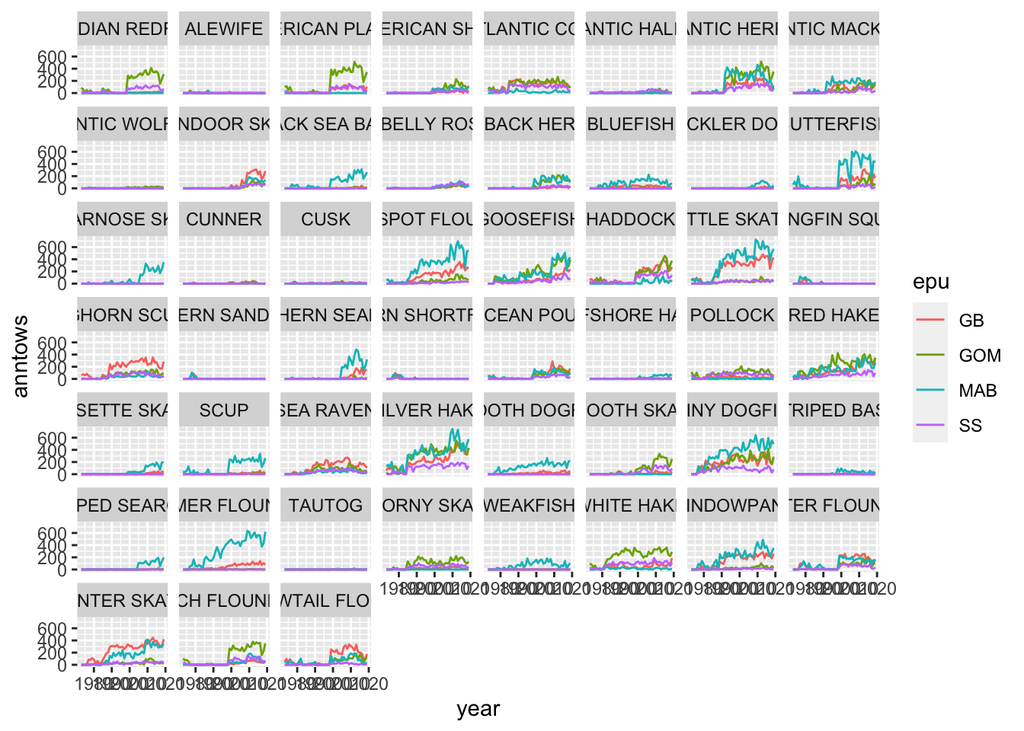

```r
# ggplot is a quick way to look across lots of things
# the aes statement sets up x and y axis variable
# with color differentiating area,
# line plot is defined with geom_line, and
# using facet_wrap does a plot for each predator (comname)

ntows %>%
  ungroup() %>%
  ggplot(aes(x=year, y=anntows, color=epu)) +
  geom_line() +
  facet_wrap(~comname)
```

There are a lot of predators! So maybe we should just look at a few. To use a `filter` statement in our code to filter down to just a few species, we need to know the exact names of the species.

Here is code to see all the species names in the dataset (the unique values in the comname column):

```r
unique(dietdat1$comname)
```

```
##  [1] "SMOOTH DOGFISH"          "SPINY DOGFISH"
##  [3] "BARNDOOR SKATE"          "WINTER SKATE"
##  [5] "CLEARNOSE SKATE"         "ROSETTE SKATE"
##  [7] "LITTLE SKATE"            "SMOOTH SKATE"
##  [9] "THORNY SKATE"            "ATLANTIC HERRING"
## [11] "ALEWIFE"                 "BLUEBACK HERRING"
## [13] "AMERICAN SHAD"           "OFFSHORE HAKE"
## [15] "SILVER HAKE"             "ATLANTIC COD"
## [17] "HADDOCK"                 "POLLOCK"
## [19] "WHITE HAKE"              "RED HAKE"
## [21] "CUSK"                    "ATLANTIC HALIBUT"
## [23] "AMERICAN PLAICE"         "SUMMER FLOUNDER"
## [25] "FOURSPOT FLOUNDER"       "YELLOWTAIL FLOUNDER"
## [27] "WINTER FLOUNDER"         "WITCH FLOUNDER"
## [29] "WINDOWPANE"              "BUCKLER DORY"
## [31] "ATLANTIC MACKEREL"       "BUTTERFISH"
## [33] "BLUEFISH"                "STRIPED BASS"
## [35] "BLACK SEA BASS"          "SCUP"
## [37] "WEAKFISH"                "ACADIAN REDFISH"
## [39] "BLACKBELLY ROSEFISH"     "LONGHORN SCULPIN"
## [41] "SEA RAVEN"               "NORTHERN SEAROBIN"
## [43] "STRIPED SEAROBIN"        "CUNNER"
## [45] "TAUTOG"                  "NORTHERN SAND LANCE"
## [47] "ATLANTIC WOLFFISH"       "OCEAN POUT"
## [49] "GOOSEFISH"               "NORTHERN SHORTFIN SQUID"
## [51] "LONGFIN SQUID"
```

Now we can choose a few and list them in the `filter` statement:

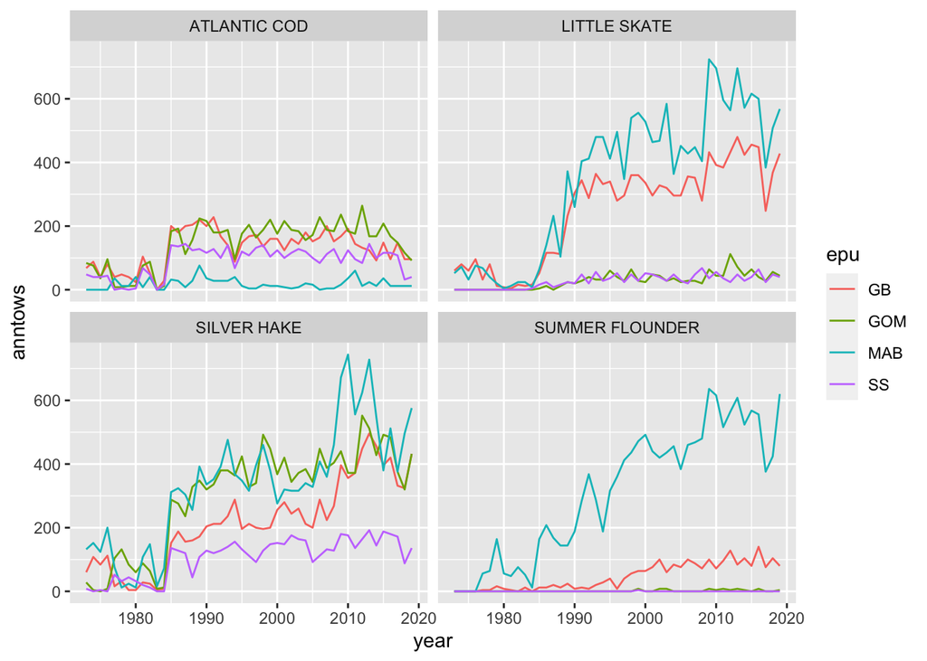

```r
# filter allows us to only look at a few species
# otherwise code is the same as above

ntows %>%
  ungroup() %>%
  filter(comname %in% c("SUMMER FLOUNDER",
                        "SILVER HAKE",
                        "LITTLE SKATE",
                        "ATLANTIC COD"
                        )) %>%
  ggplot(aes(x=year, y=anntows, color=epu)) +
  geom_line() +
  facet_wrap(~comname)
```

Now we have an idea of how many tows were sampled for diet in each area for each species over time.

You can try copying the code from each codeblock to see if this works on your computer.